# 어쩔 수가 없다 — 노동이라는 종교의 최후 신자

Culture Voyager #3 | 박찬욱의 가장 조용한 폭력

Author

Nakcho Choi

Published

May 5, 2026

## 고백부터 하자

박찬욱 신작. **“어쩔 수가 없다.”**

제목부터 졌다. 체념인가, 선언인가, 자조인가. 세 가지가 동시에 가능한 한국어의 기적이다.

한 산업에서 오래 일한 사람이라면 — 이 영화는 피부가 아니라 **뼈에 닿을 것이다.** 직장에서의 정체성이 곧 자기 자신이 된 사람이라면, 이 영화가 건드리는 신경이 어디인지 정확히 알 것이다.

## 블랙홀 장면: 만수가 아침에 집을 나서는 30초

이명세 감독은 “블랙홀처럼 모든 내용을 숨기고 있는 한 장의 장면에서 영화를 시작한다”고 했다. 박구용 교수가 그 감독론을 설명하며 한 말이다.

이 영화의 블랙홀은 여기다: **만수가 해고된 다음 날 아침, 출근하듯 양복을 입고 집을 나서는 장면.**

왜 이 30초에 영화 전체가 들어있나?

**첫째, 이것은 습관이 아니라 정체성이다.** 만수는 “출근하는 사람”이다. 그에게 출근은 행위가 아니라 존재 증명이다. 양복을 입는 것은 갑옷을 입는 것이다. 집을 나서는 것은 세상에 “나는 아직 쓸모 있다”고 선언하는 것이다.

**둘째, 이것은 거짓말이자 진실이다.** 가족에게는 거짓말 — 해고당한 걸 숨긴다. 하지만 본인에게는 진실 — 아직 노동자이고 싶다. 거짓말과 진실이 한 행동에 동시에 존재하는 것. 이것이 박찬욱이다.

**셋째, 이 장면은 한국 사회의 엑스레이다.** “뭐 하세요?”가 “안녕하세요?”를 대체한 나라. 명함이 주민등록증보다 중요한 문화. 만수가 빈 양복을 입고 나서는 것은 — 명함 없는 사람이 투명인간이 되는 사회에 대한 박찬욱의 진단이다.

## 세 가지 생산 수단 — 만수가 가진 것과 잃은 것

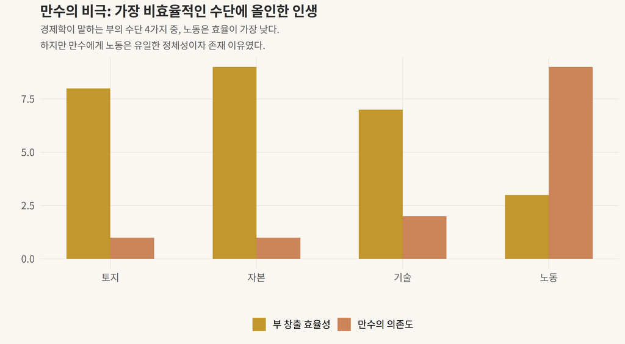

노동은 가장 비효율적인 부의 수단이다 — 하지만 만수에게는 유일한 수단이었다

경제학 원론 첫 장. 생산의 세 요소: 토지, 노동, 자본.

토지는 가만히 있어도 올라간다 (적어도 한국에서는). 자본은 복리로 불어난다. 기술은 요즘 네 번째 생산 수단으로 추가됐다.

**노동은?** 몸이 늙으면 끝이다. 시간을 팔아서 돈을 버는 구조. 시간은 한정되어 있고, 몸은 확실히 닳는다.

만수는 노동에 올인한 사람이다. 성실함. 근면함. 새벽같이 일어나 출근. 야근. 회식. “회사가 나를 알아줄 것이다.” IMF 이전에 입사한 세대의 신앙이다.

그런데 그 신앙이 배신한다. 항상 그렇듯이.

## 박찬욱의 설계 — 왜 이 소재인가

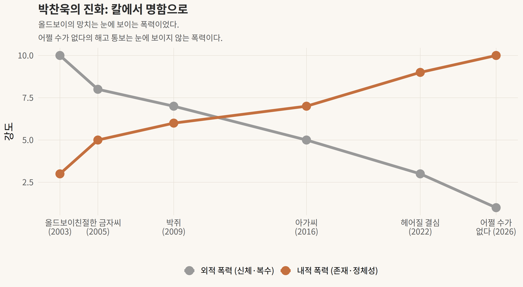

박찬욱 필모그래피의 변화 — 외적 폭력에서 내적 폭력으로

올드보이(2003)의 박찬욱은 망치로 사람을 때렸다. 복수의 화학. 눈에 보이는 폭력.

그런데 20년이 지났다. 헤어질 결심(2022)에서는 이미 폭력이 내면화되기 시작했다. 사랑이라는 이름의 자기 파괴.

**어쩔 수가 없다(2026)**에서 박찬욱의 폭력은 완전히 보이지 않게 되었다. 해고 통보. 퇴직금 정산. “수고하셨습니다.” 피 한 방울 안 나는데, 사람이 죽는다.

이것이 박찬욱의 진화다. **칼에서 명함으로.** 가장 잔인한 폭력은 “당신은 더 이상 필요 없습니다”라는 한 줄짜리 메일이다.

## 노동의 종교 — 스피노자가 만수를 만났다면

한국에서 노동은 종교다. 농담이 아니다.

- **교리**: 성실하면 보상받는다
- **예배**: 매일 아침 출근
- **성전**: 회사
- **사제**: 상사
- **면죄부**: 성과급
- **파문**: 해고

만수는 이 종교의 가장 독실한 신자였다. 그리고 파문당했다.

스피노자라면 이렇게 물었을 것이다: “만수의 노동은 자유 행위였는가, 아니면 예속이었는가?” 스피노자에게 자유란, 자기 본성의 필연에 따라 행위하는 것이다. 만수의 노동이 진짜 자기 본성에서 나온 것이었다면 — 해고되어도 흔들리지 않아야 한다.

하지만 만수는 무너졌다. 그러니까 **만수의 노동은 자유가 아니라 예속이었다.** 사회가 “너는 노동자여야 한다”고 명령한 것이고, 만수는 그 명령을 자기 목소리로 착각한 것이다.

이것이 푸코가 말한 “일상은 전쟁의 결과”다. 만수가 매일 아침 양복을 입고 나서는 것은 자유 의지가 아니라, 전쟁에서 진 자의 항복 의식이다.

## 우리 안의 만수 — 공감의 지도

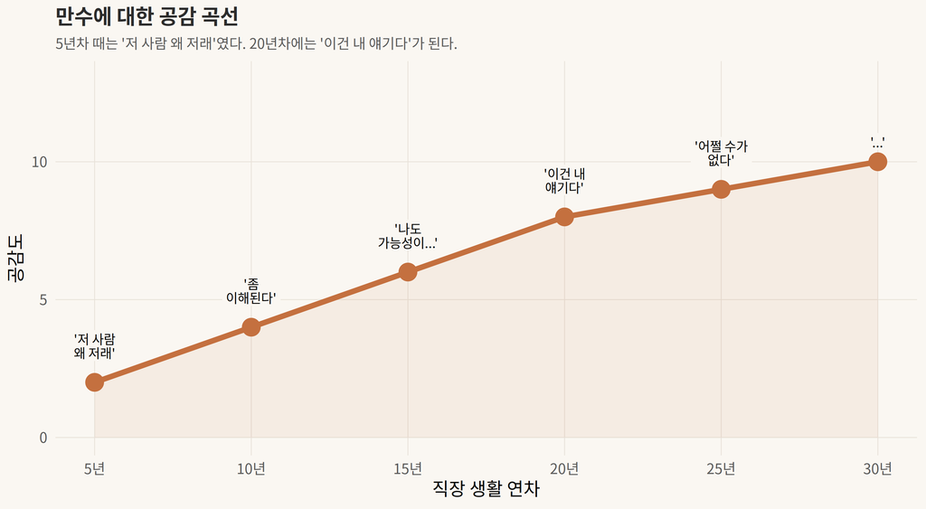

만수에게 공감하는 정도는 직장 생활 연차에 비례한다

만수를 보며 누구나 생각할 것이다. “나도 언젠가 회사를 떠나는 날이 온다. 그날 나는 뭘로 나를 설명할 수 있나?”

**명함이 없는 나는 누구인가?**

IMF 이전에 입사한 세대는 “회사가 나를 지켜줄 것”이라 믿었다. IMF 이후 세대는 그 환상이 깨진 걸 봤으면서도 — 결국 같은 짓을 하고 있다. 매일 출근하고, 성실하면 보상받을 거라 믿으며, 뼈가 닳도록 일한다.

**퇴직 후에는 노동 소득이 아니라 자본 소득으로 먹고살아야 한다.** 이 문장을 머리로는 알지만 몸으로 실천하기가 — 어쩔 수가 없다.

아, 이 영화 제목이 여기서 울린다.

## 판결 — 예술의 법정에 세우다

이 영화를 예술의 법정에 세운다.

**기소 요지:** 박찬욱은 20년간 스타일리스트로 불렸다. 화려한 영상, 정교한 복수극, 미장센의 마술사. 하지만 그 화려함이 내용을 가릴 때도 있었다. 이 영화는 다른가?

**변호:** 어쩔 수가 없다에서 박찬욱은 화려함을 거의 포기했다. 올드보이의 복도 신도, 아가씨의 정원도 없다. 대신 **양복을 입고 텅 빈 거리를 걷는 중년 남자**가 있다. 이것이 박찬욱이 20년 걸려 도달한 경지라면 — 졌다.

**판결:**

시간을 이기는 영화인가? — **그렇다.** 노동이 인간의 조건인 한, 이 영화는 계속 유효하다. 오히려 AI가 노동을 대체할수록 이 영화의 울림은 더 커질 것이다. 만수의 세계가 현실이 되고 있으니까.

## AI 시대의 추신 — 네 번째 생산 수단

경제학의 생산 수단에 네 번째를 추가해야 한다: **기술.** 그리고 2026년의 기술은 AI다. 노동을 대체하는 게 아니라, **한 사람이 할 수 있는 일의 범위를 넓혀버려서** 나머지가 필요 없게 만드는 것이다.

만수가 이 시대에 태어났다면 — AI와 함께 자기 전문성을 다시 포장할 수 있었을까? 아니면 여전히 양복을 입고 텅 빈 거리를 걸었을까?

**“어쩔 수가 없다”는 체념이 아니다. 전환의 선언이다.**

노동의 종교에서 나와야 한다. 명함이 아니라, 내가 만들 수 있는 것으로 나를 정의해야 한다.

> “어쩔 수가 없다” — 이것은 한탄이 아니라, 이제 다른 방법을 찾겠다는 선언이다.

*다음 호: 인터스텔라 — 놀란은 왜 5차원을 ’책장’으로 설계했는가*

*Culture Voyager Vol.03 | 2026.05.05*